# Beyond MLR Lab 6: Guest capacity and neighborhood walkability

Model answers · Week 3

# Guest capacity and nightly price

We study the same 826 entire-home listings in 36 Chicago neighborhoods as in Lab 5. The outcome is the natural logarithm of the listed price in dollars per night. Guest capacity is the number of people a home can accommodate.

Lab 5 estimated the difference in expected log nightly price associated with one additional guest place. The model assumed the same capacity slope in every neighborhood. WalkScore shifted the fitted lines up or down, and the lines were parallel.

Here we allow each neighborhood to have its own capacity slope. We estimate how much the slopes vary across neighborhoods and ask whether they tend to be steeper in more walkable neighborhoods.

# Setup and data

Save your script as `lab6.R` in the `week3` folder and set that folder as your working directory. Save the Chicago Airbnb data as `data/airbnb.csv` inside `week3`. Install the packages with `pak` if needed, as in Lab 1.

```r
library(pak)
pkg_install(c("dplyr", "ggplot2", "lmerTest", "emmeans"))
```

```r
library(dplyr)
library(ggplot2)
library(lmerTest)

airbnb <- read.csv("data/airbnb.csv")
airbnb <- filter(airbnb, room_type == "Entire home/apt")
airbnb$neighborhood <- factor(airbnb$neighborhood)
airbnb$log_price <- log(airbnb$price)
airbnb$capacity_c <- airbnb$accommodates - 4
airbnb$walk10 <- (airbnb$WalkScore - 80) / 10
```

A four-guest home has `capacity_c = 0`, and a five-guest home has `capacity_c = 1`. A neighborhood with WalkScore 80 has `walk10 = 0`. Each additional ten WalkScore points increases `walk10` by one.

# Plot log nightly price against guest capacity

The six neighborhoods with the most entire-home listings each have their own panel. All six panels use the same axis scales, so a steeper line indicates a larger difference in log price per additional guest place.

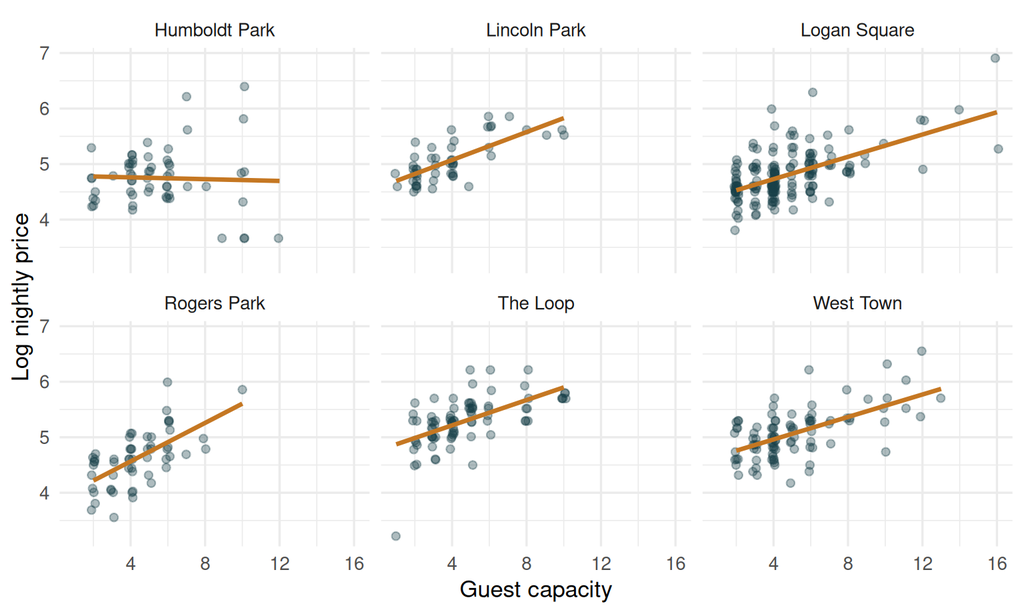

```r
top_six <- count(airbnb, neighborhood, sort = TRUE) |>
  slice_head(n = 6)

homes <- filter(airbnb, neighborhood %in% top_six$neighborhood)

ggplot(homes, aes(accommodates, log_price)) +
  geom_point(position = position_jitter(width = 0.12, height = 0, seed = 6),
             alpha = 0.35, color = "#173F48") +
  geom_smooth(method = "lm", formula = y ~ x, se = FALSE, color = "#C57722") +
  facet_wrap(~ neighborhood, ncol = 3) +
  labs(x = "Guest capacity", y = "Log nightly price") +
  theme_minimal(base_size = 13)
```

Each dot represents a listing. Homes with the same capacity are spread slightly apart on the horizontal axis so that individual listings are easier to see. The fitted line in each panel comes from a separate regression using the original guest capacities.

**ImportantQuestion 1**

Looking across the six neighborhoods, does a common capacity slope seem reasonable? Explain which features of the fitted lines inform your judgment.

**TipModel answer 1**

The line in Rogers Park slopes upward, while the line in Humboldt Park is nearly flat. A common capacity slope would give parallel model lines. The differences among the fitted lines suggest that a common slope may be too restrictive. Sampling variation also contributes to differences among the slopes estimated separately in the six panels.

# Fit a random intercept and a random capacity slope

The fitted lines suggest that an additional guest place is associated with a larger difference in log nightly price in some neighborhoods than in others. A random capacity slope lets us estimate how much the slopes vary. As in Lab 5, the model includes WalkScore and a random neighborhood intercept.

$$L_{ij}=(\beta_0+c_j)+(\beta_1+b_j)C_{ij}
+\beta_2 W_j+\varepsilon_{ij}.$$

For listing $i$ in neighborhood $j$, $L_{ij}$ is log nightly price and $C_{ij}$ is centered guest capacity. $W_j$ is the centered and rescaled WalkScore. For a four-guest home, $c_j$ is the amount by which the neighborhood mean log price differs from the mean predicted by WalkScore. The capacity slope in that neighborhood is $\beta_1+b_j$, where $\beta_1$ is the average slope and $b_j$ is the neighborhood’s deviation from that average.

```r
model_slope <- lmer(log_price ~ capacity_c + walk10 +
                      (1 + capacity_c | neighborhood), data = airbnb)
summary(model_slope)
```

```
Linear mixed model fit by REML. t-tests use Satterthwaite's method [
lmerModLmerTest]
Formula: log_price ~ capacity_c + walk10 + (1 + capacity_c | neighborhood)
   Data: airbnb

REML criterion at convergence: 812.4

Scaled residuals:
    Min      1Q  Median      3Q     Max
-4.5289 -0.5536 -0.0692  0.5309  4.3477

Random effects:
 Groups       Name        Variance Std.Dev. Corr
 neighborhood (Intercept) 0.034026 0.18446
              capacity_c  0.002706 0.05202  0.04
 Residual                 0.140099 0.37430
Number of obs: 826, groups:  neighborhood, 36

Fixed effects:
            Estimate Std. Error       df t value Pr(>|t|)
(Intercept)  4.70875    0.04017 23.89523 117.216  < 2e-16 ***
capacity_c   0.09037    0.01308 16.66773   6.911 2.81e-06 ***
walk10       0.14602    0.04097 34.10932   3.564   0.0011 **
---
Signif. codes:  0 '***' 0.001 '**' 0.01 '*' 0.05 '.' 0.1 ' ' 1

Correlation of Fixed Effects:
           (Intr) cpcty_
capacity_c -0.051
walk10     -0.138  0.017
```

We can judge the size of the differences between neighborhood slopes by comparing their standard deviation (SD) with the average slope. The standard deviation is the square root of the slope variance, so both the SD and the average slope are in log-price units per additional guest place. In the `capacity_c` row, read the average slope under **Fixed effects** and the SD under **Random effects** (`Std.Dev.`).

**ImportantQuestion 2**

Within the same neighborhood, what is the estimated difference in expected log nightly price between a five-guest and a four-guest home, on average across neighborhoods? Report the estimate and its standard error.

**ImportantQuestion 3**

Under the model’s Normal distribution, what range contains the middle 68% of neighborhood capacity slopes? Use this range to explain how much the association between guest capacity and nightly price varies across neighborhoods.

**ImportantQuestion 4**

After accounting for WalkScore, what does the estimated intercept–slope correlation tell you about the relationship between a neighborhood’s expected log price for a four-guest home and its capacity slope?

**TipModel answer 2**

Across neighborhoods, a five-guest home has an expected log nightly price **0.0904 units higher** on average than a four-guest home in the same neighborhood. The estimated standard error of **0.0131** describes the uncertainty about that average slope.

**TipModel answer 3**

The middle 68% of neighborhood slopes lie within one SD of the average under the fitted Normal model. This gives $0.090 \pm 0.052$, or **0.038 to 0.142 log-price units per additional guest place**.

In a neighborhood at the lower end of this range, the expected log nightly price is 0.038 units higher for a five-guest home than for a four-guest home. In a neighborhood at the upper end, the same comparison gives a difference of 0.142 units.

**TipModel answer 4**

The estimated correlation is **+0.04**, close to zero. Among neighborhoods with similar WalkScores, the expected log price for four-guest homes tells us little about how steeply log price rises with capacity.

# Add the interaction between capacity and WalkScore

In the random-slope model, individual neighborhoods have their own capacity slopes. At every WalkScore, those slopes vary around the same average, $\beta_1$. Adding $\beta_3 C_{ij}W_j$ lets us ask whether the average difference in log price between a five-guest and a four-guest home changes with neighborhood walkability. This is a **cross-level interaction** because capacity describes a listing and WalkScore describes its neighborhood. The full model for log nightly price is

$$L_{ij}=(\beta_0+c_j)+(\beta_1+b_j)C_{ij}
+\beta_2 W_j+\beta_3 C_{ij}W_j+\varepsilon_{ij}.$$

Collecting the terms that multiply $C_{ij}$ gives the capacity slope in neighborhood $j$, $\beta_1+b_j+\beta_3 W_j$. At WalkScore 80, $W_j=0$ and the average slope is $\beta_1$. At WalkScore 90, $W_j=1$ and the average slope is $\beta_1+\beta_3$. The neighborhood deviation $b_j$ tells us how far a particular slope lies above or below the average at that WalkScore.

```r
model_interaction <- lmer(
  log_price ~ capacity_c + walk10 + capacity_c:walk10 +
    (1 + capacity_c | neighborhood),
  data = airbnb
)
summary(model_interaction)
```

```
Linear mixed model fit by REML. t-tests use Satterthwaite's method [
lmerModLmerTest]
Formula:
log_price ~ capacity_c + walk10 + capacity_c:walk10 + (1 + capacity_c |
    neighborhood)
   Data: airbnb

REML criterion at convergence: 812.8

Scaled residuals:
    Min      1Q  Median      3Q     Max
-4.6179 -0.5591 -0.0628  0.5326  4.2921

Random effects:
 Groups       Name        Variance Std.Dev. Corr
 neighborhood (Intercept) 0.029990 0.17318
              capacity_c  0.002078 0.04559  -0.15
 Residual                 0.140463 0.37478
Number of obs: 826, groups:  neighborhood, 36

Fixed effects:
                  Estimate Std. Error       df t value Pr(>|t|)
(Intercept)        4.71138    0.03859 27.34243 122.103  < 2e-16 ***
capacity_c         0.07590    0.01352 36.60437   5.615 2.16e-06 ***
walk10             0.15455    0.03946 37.55033   3.916 0.000367 ***
capacity_c:walk10  0.03983    0.01537 36.92137   2.591 0.013615 *
---
Signif. codes:  0 '***' 0.001 '**' 0.01 '*' 0.05 '.' 0.1 ' ' 1

Correlation of Fixed Effects:
            (Intr) cpcty_ walk10
capacity_c  -0.167
walk10      -0.159 -0.021
cpcty_c:w10  0.021 -0.463 -0.020
```

**ImportantQuestion 5**

For a ten-point increase in WalkScore, by how much does the estimated capacity slope change? Interpret the direction of the change and use the p-value to assess the evidence for the interaction.

Under **Random effects**, the `capacity_c` variance now describes how much neighborhood slopes vary around the average slope at their WalkScore.

**ImportantQuestion 6**

How does adding the interaction change the estimated between-neighborhood variance in capacity slopes? Express the change as a percentage. What does the remaining variance tell you about neighborhoods with the same WalkScore?

**TipModel answer 5**

For each ten-point increase in WalkScore, the estimated capacity slope increases by **0.0398 log-price units per additional guest place**. The estimated difference in log nightly price associated with accommodating one more guest is therefore larger in more walkable neighborhoods. The interaction is statistically significant at the 5% level ($p=0.014$).

**TipModel answer 6**

The estimated capacity-slope variance falls from **0.002706** to **0.002078**. The reduction is about **23%**.

$$100 \times \frac{0.002706-0.002078}{0.002706} \approx 23\%.$$

Even at the same WalkScore, neighborhoods can differ in how much log price increases per additional guest place. The remaining variance corresponds to an SD of about 0.046 log-price units per guest place ($\sqrt{0.002078}$) around the average slope at that WalkScore.

# Compare four-guest and five-guest homes at two WalkScores

The significant interaction indicates that the association between guest capacity and log nightly price depends on neighborhood walkability. We interpret the interaction by examining the **simple effects of guest capacity**. At a given WalkScore, the simple effect is the difference in expected log nightly price between a five-guest home and a four-guest home.

We want to see how large this price gap is in less walkable and more walkable neighborhoods. We therefore estimate it at the lower and upper quartiles of WalkScore among the listings.

```r
quantile(airbnb$WalkScore, c(0.25, 0.75))
```

```
25% 75%
 85  91
```

## Estimate mean log nightly prices

A **reference grid** lists the combinations of predictor values at which `emmeans()` makes predictions from the fitted model. Guest capacity and WalkScore are both numerical predictors in this model. By default, `emmeans()` sets each of them to its sample mean, so the grid contains just one combination and gives us one estimated mean log nightly price.

For the simple effect at WalkScore 85, we need a fitted mean for four-guest homes and another for five-guest homes. We need the same pair at WalkScore 91. We use `at` to supply the two values of each predictor on the scales used to fit the model. This gives us all four combinations.

- `capacity_c = c(4, 5) - 4` requests centered capacities 0 and 1, representing homes for four and five guests.
- `walk10 = (c(85, 91) - 80) / 10` requests 0.5 and 1.1 on the model scale, representing WalkScores 85 and 91.

In `~ capacity_c | walk10`, the vertical bar groups the fitted means by WalkScore. These fitted means use the fixed effects and describe the expected log price averaged over neighborhoods at the specified WalkScore. Setting `lmer.df = "satterthwaite"` uses the same degrees-of-freedom method as the model summary.

```r
library(emmeans)
capacity_means <- emmeans(
  model_interaction, ~ capacity_c | walk10,
  at = list(capacity_c = c(4, 5) - 4, walk10 = (c(85, 91) - 80) / 10),
  lmer.df = "satterthwaite"
)
print(capacity_means, digits = 4)
```

```
walk10 = 0.5:
 capacity_c emmean     SE   df lower.CL upper.CL
          0   4.79 0.0404 17.1     4.70     4.87
          1   4.88 0.0400 14.1     4.80     4.97

walk10 = 1.1:
 capacity_c emmean     SE   df lower.CL upper.CL
          0   4.88 0.0533 16.7     4.77     4.99
          1   5.00 0.0538 14.0     4.89     5.12

Degrees-of-freedom method: satterthwaite
Confidence level used: 0.95
```

For example, the row with `capacity_c = 1` and `walk10 = 0.5` represents a five-guest home at WalkScore 85. Its fitted mean log nightly price is 4.88.

## Compare the capacity contrasts

We plot the four fitted means to compare the simple effects of guest capacity at WalkScores 85 and 91. We join the four-guest and five-guest means at each WalkScore. The vertical change from the first point to the second gives the estimated difference in mean log nightly price at that WalkScore.

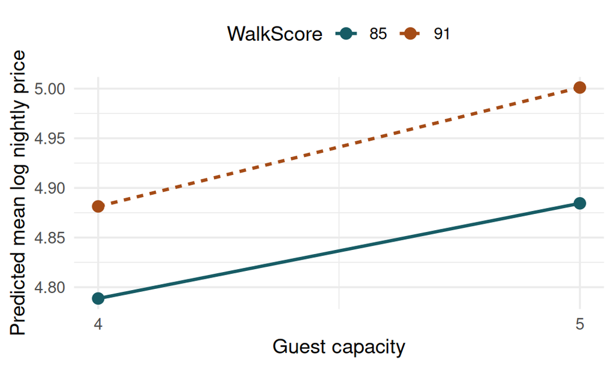

```r
plot_means <- as.data.frame(capacity_means)
plot_means$guests <- plot_means$capacity_c + 4
plot_means$WalkScore <- factor(80 + 10 * plot_means$walk10)

ggplot(plot_means, aes(guests, emmean, color = WalkScore, linetype = WalkScore)) +
  geom_line(linewidth = 1) +
  geom_point(size = 3) +
  scale_x_continuous(breaks = c(4, 5)) +
  scale_color_manual(values = c("#175C65", "#A54B16")) +
  labs(x = "Guest capacity", y = "Predicted mean log nightly price") +
  theme_minimal(base_size = 13) +
  theme(legend.position = "top")
```

At each WalkScore, `pairs()` with `reverse = TRUE` subtracts the four-guest mean from the five-guest mean. The `estimate` column reports that simple effect in log-price units.

```r
capacity_effects <- pairs(capacity_means, reverse = TRUE)
print(capacity_effects)
```

```
walk10 = 0.5:
 contrast                  estimate     SE   df t.ratio p.value
 capacity_c1 - capacity_c0   0.0958 0.0121 16.0   7.943 <0.0001

walk10 = 1.1:
 contrast                  estimate     SE   df t.ratio p.value
 capacity_c1 - capacity_c0   0.1197 0.0160 13.8   7.470 <0.0001

Degrees-of-freedom method: satterthwaite
```

**ImportantQuestion 7**

Compare five-guest and four-guest homes at WalkScores 85 and 91. What is the estimated difference in mean log nightly price at each WalkScore? What do these two estimates tell you about the interaction?

**TipModel answer 7**

Five-guest homes have a higher estimated mean log nightly price than four-guest homes at both WalkScores. The difference is **0.0958 log-price units** at 85 and **0.1197** at 91. The gap is **0.0239 log-price units larger** at WalkScore 91 (0.1197 − 0.0958).